# Migration Rates by State by Education, Ethnicity, and Age

Source: American Community Survey 2023

Author

Mark Ellis

Published

Feb 12, 2026

# 1 Read in and process the data

## 1.1 Set libraries and directories

# 2 This analysis uses 2023 ACS data from IPUMS USA, University of Minnesota, www.ipums.org

```r
library(ipumsr)
library(tidyverse)
library(gt)
library(scales)
library(sf)

# wkdir is the root of your project directory
wkdir <- here::here()

# set directories for where you store data and save plots relative to project root
dataDir <- file.path(wkdir, "data")  #read data file dir
plotsDir <- file.path(wkdir, "plots")  #save plot files dir

options(scipen=99, digits=5)

# create plots directory if it does not exist
ifelse(!dir.exists(file.path(wkdir, "plots")), dir.create(file.path(wkdir, "plots")), FALSE)


options(scipen=99, digits = 5)
```

## 2.1 Read the data

Use the same extract download as for the first assignment

This analysis uses 2023 ACS data from IPUMS USA, University of Minnesota, www.ipums.org.

```r
if (!require("ipumsr")) stop("Reading IPUMS data into R requires the ipumsr package. It can be installed using the following command: install.packages('ipumsr')")

dataSet <- "usa_00001.xml"  # name of YOUR 2023 xml file

ddi <- read_ipums_ddi(file.path(dataDir,dataSet)) # ACS 2023
data <- read_ipums_micro(ddi)
data <- data %>%
  filter(YEAR != 2000)

# extract variable names the traditional way (useful reference)
varname <- as.data.frame(colnames(data))

# create webpage of variable names, labels and values, save it as dataSet.html in the data directory
# useful for reference
ipums_view(ddi, launch = FALSE, out_file=file.path(wkdir, "data", paste0(dataSet,".html" )))

# add a state name variable to data
# first, create a dataframe with statefips codes (as val) and statenames (as lbl) from variable STATEIP
STATES <- ipums_val_labels(ddi, STATEFIP)

# then, join STATES to data (using: STATEFIP=val) and rename new variable lbl as STATENAME
data <- data %>%
  left_join(select(STATES, STATEFIP=val, STATENAME=lbl))
```

## 2.2 Create a previous state of residence variable for counting 2022 population

- MIGPLAC1 is state of residence 1 year ago. It has a code of 0 for those whose current state is the same as the state 1 year ago.
- Assign STATEFIP to MIGPLAC1 for those whose state of residence in the sample year is the same as 1 year prior (i.e. those who didn’t move across state lines)
  - If we don’t do this all those who didn’t migrate will retain a MIGPLAC1 code of 0 and will not be counted as part of the population of the state lived in the prior year.
- Create a new variable called PREV_STATENAME from the labels for MIGPLAC1; these are the names of the states people lived in 1 year prior

```r
# assign current state of residence to previous state for those who didn't move
# (i.e. MIGPLAC1=0)
data <- data %>%
#  filter(AGE>=1) %>%
  mutate(MIGPLAC1=case_when(
    AGE>=1 & MIGPLAC1 == 0 ~ STATEFIP,
    TRUE ~ as.integer(MIGPLAC1)))


# make a new variable called PREV_STATENAME from MIGPLAC1 labels
MIGPLAC1 <- ipums_val_labels(ddi, MIGPLAC1)

# add MIGPLAC1 labels to our data extract as new variable PREV_STATENAME
data$PREV_STATENAME <- as_factor(data$MIGPLAC1)
```

# 3 State Migration Rates

## 3.1 Calculate migration rates by origin state

Using PREV_STATENAME as our grouping variable, we can correctly calculate migration rates based on where people lived before they migrated i.e. 1 year prior.

```r
migrate_state_origin <- data %>%
  filter(AGE>=1 & MIGPLAC1<=56) %>% # those >= 1 and those who lived in the US 1 year prior
  group_by(PREV_STATENAME) %>%
  summarise(pop_origin=sum(PERWT),
         interstate_movers_origin=sum(PERWT[MIGRATE1==3])) %>%
  mutate(interstate_mig_rate_origin=interstate_movers_origin/pop_origin)

gt(head(migrate_state_origin))
```

| State (FIPS code) | pop_origin | interstate_movers_origin | interstate_mig_rate_origin |
| --- | --- | --- | --- |
| Alabama | 5025459 | 101870 | 0.020271 |
| Alaska | 718714 | 36206 | 0.050376 |
| Arizona | 7247081 | 193757 | 0.026736 |
| Arkansas | 3014253 | 65211 | 0.021634 |
| California | 38496762 | 682598 | 0.017731 |
| Colorado | 5757032 | 209052 | 0.036312 |

## 3.2 Read in shapefile and join the data to the shapefile

Read in the same shapefile I shared with you in Week 4. It should be in a Shapefiles directory under the directory where you save your codefile.

Join migrate_state_origin to the shapefile shapes_shp

```r
# Read shapefile
states_shp <- st_read(file.path(wkdir, "Shapefiles", "states_moveAKHI.shp"),"states_moveAKHI", quiet = TRUE)

# join the migration rate by origin data to the shapefile
states_shp <- states_shp %>%
  left_join(migrate_state_origin, by = c("STATE_NAME" = "PREV_STATENAME"))
```

## 3.3 Map state migration rates

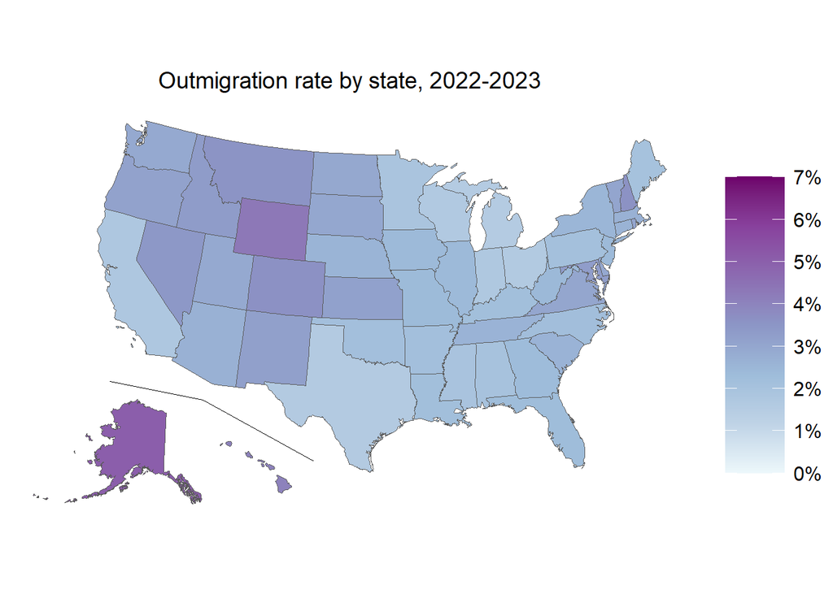

```r
p2 <- ggplot() +
  geom_sf(data = states_shp, aes(fill=interstate_mig_rate_origin), size=0.1) +
  coord_sf(crs = "epsg:5070") +
  geom_segment(aes(x = -2250000, y = 1050000, xend = -1500000, yend = 900000), size=0.2) +
  geom_segment(aes(x = -1500000, y = 900000, xend = -600000, yend = 400000), size=0.2) +
  scale_fill_distiller(name=' ', palette='BuPu',direction=1,
                      breaks=c(.0, .01, .02, .03, .04, .05, .06, .07),
                      labels=label_percent(accuracy = 1),
                      limits=c(0,.07)) +
  labs(title = "Outmigration rate by state, 2022-2023") +
  theme(panel.grid.major = element_blank(),
        panel.grid.minor = element_blank(),
        panel.background = element_blank(),
        axis.line = element_blank(),
        axis.text.x=element_blank(),
        axis.text.y=element_blank(),
        axis.ticks=element_blank(),
        axis.title=element_blank(),
        legend.key.size =  unit(0.5, "in"),
        legend.text = element_text(size=12),
        legend.title = element_text(size=10),
        plot.title = element_text(size=14,hjust = 0.5),
        plot.subtitle = element_text(hjust = 0.5),
        plot.margin=unit(c(1, 1, 1, 1), "points"),
        strip.background = element_rect(fill='white'),
        strip.text.x = element_text(size = 10))
p2
```

# 4 State migration rates by education

## 4.1 Now lets compute migration rates in states by education

We calculate four rates using a series of differing group_bys, summarises and mutates, ungrouping when necessary to apply a new group_by

The four rates we calculate are:

- interstate_mig_rate_state_edlevel: state migration rates by education
- interstate_mig_rate_all: the national migration rate (overall, not by education)
- interstate_mig_rate_state: state migration rates (overall, not by education)
- interstate_mig_rate_edlevel: national migration rates by education

We will map the first of these only: interstate_mig_rate_state_edlevel. The other rates are useful as denominators in location quotients - see later section.

```r
# compute state migration rates: all, by state,  by state and education level
migrate_educ_states <- data %>%
  filter(AGE>=25 & MIGPLAC1 <=56) %>% # those >= 1 and those who lived in the US 1 year prior
  mutate(Education=case_when(
    EDUCD <= 64 ~ "HS or Less",
    EDUCD >=65 & EDUCD <=100 ~ "Some College",
    EDUCD >= 101 & EDUCD <= 113 ~ "BA degree",
    EDUCD >= 114 ~ "Advanced Degree")) %>%
  group_by(PREV_STATENAME, Education) %>%
  summarise(pop_state_edlevel=sum(PERWT),
         interstate_movers_state_edlevel=sum(PERWT[MIGRATE1==3])) %>%
  mutate(interstate_mig_rate_state_edlevel=interstate_movers_state_edlevel/pop_state_edlevel) %>%
  ungroup() %>%
  mutate(interstate_mig_rate_all=sum(interstate_movers_state_edlevel)/sum(pop_state_edlevel)) %>%
  group_by(PREV_STATENAME) %>%
  mutate(interstate_mig_rate_state=sum(interstate_movers_state_edlevel)/sum(pop_state_edlevel)) %>%
  group_by(Education) %>%
  mutate(interstate_mig_rate_edlevel=sum(interstate_movers_state_edlevel)/sum(pop_state_edlevel))
```

## 4.2 Calculate some location quotients

For further analysis lets compute some LQs of these migration rates. These are the rates of migration by education in each state divided by a reference rate.

Values of 1 indicate that the state rate of migration by education equals the reference rate. Values below 1 indicate the state rate of migration by education is below the reference rate. Values above one means its above the reference rate.

We will calculate two location quotients:

- state migration rates by education level / overall state migration rate
- state migration rates by education / national migration rates by education

These are added to the migrate_educ_states dataframe we created in the previous code chunk

```r
migrate_educ_states <-migrate_educ_states %>%
  ungroup() %>%
  mutate(lq_interstate_mig_rate_state=interstate_mig_rate_state_edlevel/interstate_mig_rate_state) %>%
  mutate(lq_interstate_mig_rate_edlevel=interstate_mig_rate_state_edlevel/interstate_mig_rate_edlevel)
```

## 4.3 Join the migration by state by education data to the shapefile

Note the right_join. See comments in code.

```r
# join our rates and lqs to the shapefile (we must use a right join here because we
# want to keep all rows in migrate_educ_states)
states_shp2 <- states_shp %>%
  right_join(migrate_educ_states, by = c("STATE_NAME" = "PREV_STATENAME"))
```

## 4.4 Map of state rates by education

Here we use facet_wrap to map state rates of migration by education on one image with four panels.

Compare the ggplot code here with the ggplot code used to produce the first map above to see how the code has been tweaked to make this work.

There is a lot of information in these four panels.

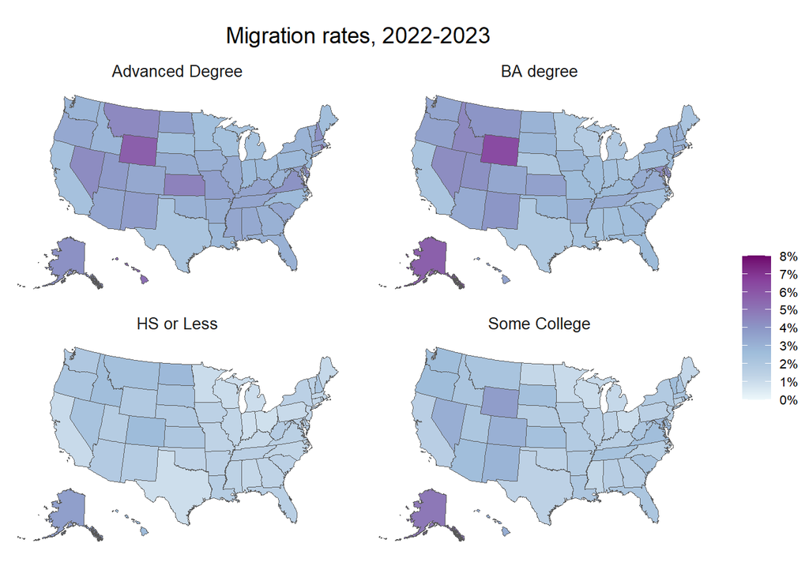

```r
# join our rates and lqs to the shapefile (we use a right join here because we
# want to keep all rows in migrate_educ_states)
states_shp2 <- states_shp %>%
  right_join(migrate_educ_states, by = c("STATE_NAME" = "PREV_STATENAME"))

ggplot() +
  geom_sf(data = states_shp2, aes(fill=interstate_mig_rate_state_edlevel), size=0.1) +
  coord_sf(crs = "epsg:5070") +
  scale_fill_distiller(name=' ', palette='BuPu',direction=1,
                      breaks=c(.0, .01, .02, .03, .04, .05, .06, .07, .08),
                      labels=label_percent(accuracy = 1),
                      limits=c(0,.08)) +
  labs(title = "Migration rates, 2022-2023") +
  theme(panel.grid.major = element_blank(),
        panel.grid.minor = element_blank(),
        panel.background = element_blank(),
        axis.line = element_blank(),
        axis.text.x=element_blank(),
        axis.text.y=element_blank(),
        axis.ticks=element_blank(),
        axis.title=element_blank(),
        legend.key.size =  unit(0.25, "in"),
        legend.text = element_text(size=8),
        legend.title = element_text(size=6),
        plot.title = element_text(size=14,hjust = 0.5),
        plot.subtitle = element_text(hjust = 0.5),
        plot.margin=unit(c(1, 1, 1, 1), "points"),
        strip.background = element_rect(fill='white'),
        strip.text.x = element_text(size = 10)) +
  facet_wrap(~Education)
```

## 4.5 Location quotients of state migration rates by education relative to overall state migration rates

This maps lq_interstate_mig_rate_state: calculated as State migration rate by education / Overall state migration rate.

It show whether an education group’s migration rate in a state departs from the overall state migration rate and how how much.

This map of location quotients allows us to see how much each education group’s migration rate differs from the aggregate state migration rate. You can see the purples for those with a BA or advanced degree, meaning their group rates are above the state rate, unsurprisingly. This is the case in a cluster of states un the middle and midwest of the country. The shades of purple are lighter in Washington, California and other states, meaning those with BAs or advanced degrees are not apt to leave these states at higher rates than other educational groups. This is perhaps a sign that these state’s economies can absorb highly educated labor more readily.

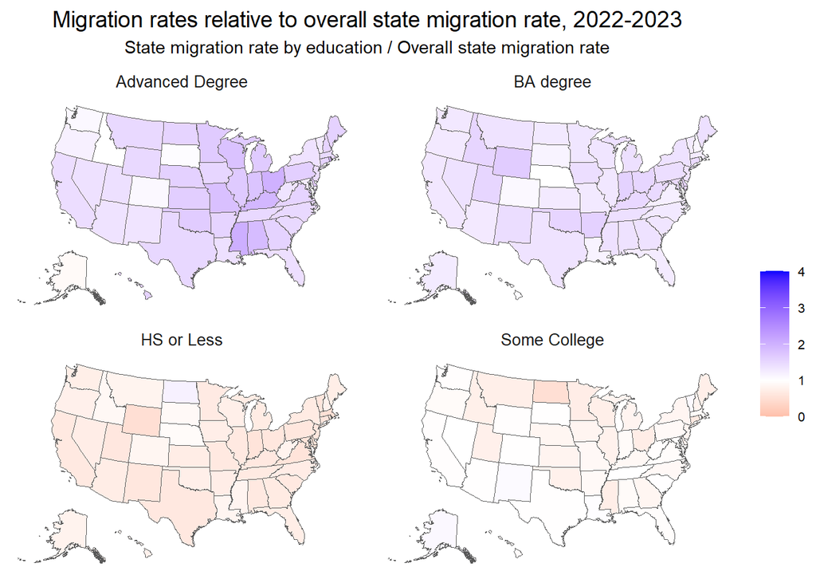

```r
ggplot() +
  geom_sf(data = states_shp2, aes(fill=lq_interstate_mig_rate_state), size=0.1) +
  coord_sf(crs = "epsg:5070") +
  scale_fill_gradient2(name=' ', low="red", mid="white", high="blue",
                       midpoint=1, limits=c(0,4)
  ) +
  labs(title = "Migration rates relative to overall state migration rate, 2022-2023",
       subtitle = "State migration rate by education / Overall state migration rate") +
  theme(panel.grid.major = element_blank(),
        panel.grid.minor = element_blank(),
        panel.background = element_blank(),
        axis.line = element_blank(),
        axis.text.x=element_blank(),
        axis.text.y=element_blank(),
        axis.ticks=element_blank(),
        axis.title=element_blank(),
        legend.key.size =  unit(0.25, "in"),
        legend.text = element_text(size=8),
        legend.title = element_text(size=6),
        plot.title = element_text(size=14,hjust = 0.5),
        plot.subtitle = element_text(hjust = 0.5),
        plot.margin=unit(c(1, 1, 1, 1), "points"),
        strip.background = element_rect(fill='white'),
        strip.text.x = element_text(size = 10)) +
  facet_wrap(~Education)
```

## 4.6 Location quotients of state migration rates by education relative to national migration rates by education

This maps lq_interstate_mig_rate_educ: calculated as State migration rate by education / National migration rate by education

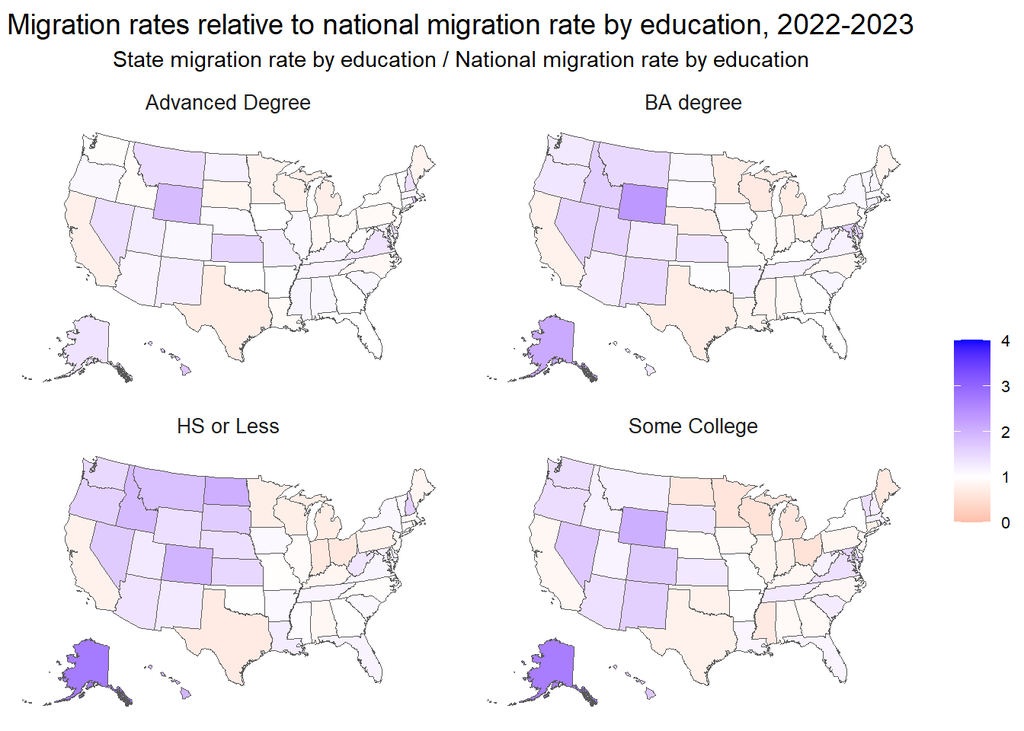

```r
ggplot() +
  geom_sf(data = states_shp2, aes(fill=lq_interstate_mig_rate_edlevel), size=0.1) +
  coord_sf(crs = "epsg:5070") +
  scale_fill_gradient2(name='',
                       low="red", mid="white", high="blue",
                       midpoint=1, limits=c(0,4)
  ) +
  labs(title = "Migration rates relative to national migration rate by education, 2022-2023",
       subtitle = "State migration rate by education / National migration rate by education") +
  theme(panel.grid.major = element_blank(),
        panel.grid.minor = element_blank(),
        panel.background = element_blank(),
        axis.line = element_blank(),
        axis.text.x=element_blank(),
        axis.text.y=element_blank(),
        axis.ticks=element_blank(),
        axis.title=element_blank(),
        legend.key.size =  unit(0.25, "in"),
        legend.text = element_text(size=8),
        legend.title = element_text(size=6),
        plot.title = element_text(size=14,hjust = 0.5),
        plot.subtitle = element_text(hjust = 0.5),
        plot.margin=unit(c(1, 1, 1, 1), "points"),
        strip.background = element_rect(fill='white'),
        strip.text.x = element_text(size = 10)) +
  facet_wrap(~Education)
```

## 4.7 We make a new data frame that separates data by ethnicity

```r
migrate_race <- data %>%
  filter(AGE>=1) %>%
  mutate(RACE_ETHNIC=case_when(
    HISPAN==0 & RACE==1 ~ "White",
    HISPAN==0 & RACE==2 ~ "Black",
    HISPAN==0 & RACE==3 ~ "American Indian",
    HISPAN==0 & (RACE>=4 & RACE <=6) ~ "Asian",
    HISPAN==0 & RACE==7 ~ "Other",
    HISPAN==0 & RACE>=8 ~ "Mixed",
    HISPAN>0 ~ "Latino")) %>%
  group_by(RACE_ETHNIC, PREV_STATENAME) %>%
  summarise(pop=sum(PERWT),
         interstate_movers=sum(PERWT[MIGRATE1==3])) %>%
  mutate(interstate_mig_rate_state_race=interstate_movers/pop)
gt(head(migrate_race)) %>%
  opt_table_font(size = 40) %>%
  cols_align(
    align = "center",
  )
```

| State (FIPS code) | pop | interstate_movers | interstate_mig_rate_state_race |
| --- | --- | --- | --- |
| American Indian |  |  |  |
| Alabama | 12990 | 737 | 0.0567360 |
| Alaska | 100361 | 1026 | 0.0102231 |
| Arizona | 226328 | 2157 | 0.0095304 |
| Arkansas | 11871 | 386 | 0.0325162 |
| California | 103313 | 3488 | 0.0337615 |
| Colorado | 19802 | 967 | 0.0488335 |

## 4.8 Now we use a right join again to keep everything from the race migration data and filter out some of the smaller ethnicities to create another panel view

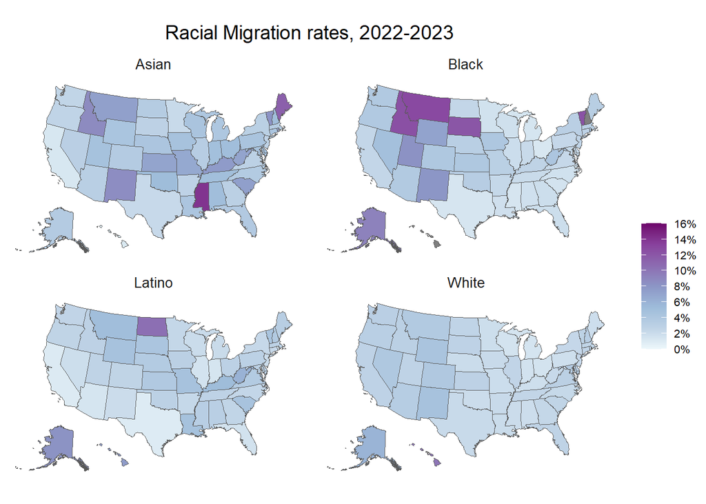

```r
states_shp3 <- states_shp %>%
  right_join(migrate_race, by = c("STATE_NAME" = "PREV_STATENAME"))

states_shp3 <- states_shp3 %>%
  filter(RACE_ETHNIC != 'American Indian',
         RACE_ETHNIC != 'Mixed',
         RACE_ETHNIC != 'Other')



ggplot() +
  geom_sf(data = states_shp3, aes(fill=interstate_mig_rate_state_race), size=0.1) +
  coord_sf(crs = "epsg:5070") +
  scale_fill_distiller(name=' ', palette='BuPu',direction=1,
                      breaks=c(.0, .02, .04, .06, .08, .1, 0.12, 0.14, 0.16),
                      labels=label_percent(accuracy = 1),
                      limits=c(0,.16)) +
  labs(title = "Racial Migration rates, 2022-2023") +
  theme(panel.grid.major = element_blank(),
        panel.grid.minor = element_blank(),
        panel.background = element_blank(),
        axis.line = element_blank(),
        axis.text.x=element_blank(),
        axis.text.y=element_blank(),
        axis.ticks=element_blank(),
        axis.title=element_blank(),
        legend.key.size =  unit(0.25, "in"),
        legend.text = element_text(size=8),
        legend.title = element_text(size=6),
        plot.title = element_text(size=14,hjust = 0.5),
        plot.subtitle = element_text(hjust = 0.5),
        plot.margin=unit(c(1, 1, 1, 1), "points"),
        strip.background = element_rect(fill='white'),
        strip.text.x = element_text(size = 10)) +
  facet_wrap(~RACE_ETHNIC)
```

If it was up to me a lot of the states that have higher percentages here have low populations in the respective states. Idaho and Montana are full of White people hence why there are not as many Black or Asian people, but Latino communities do exist in these states. North Dakota does not have many Latinos. Mississippi also does not have many Asians. I think to get more of an introspective view on this would be to adjust the percentages to observe significant discrepencies between race.

## 4.9 Calculate and make a dataframe for our age cohorts

```r
migrate_age_cohorts <- data %>%
  filter(AGE>=1) %>%
  mutate(agegroup=cut(AGE, breaks=c(0,18,31,65,500), right=F,
                      labels=c("1-17","18-30","31-64", "65+"))) %>%
  group_by(PREV_STATENAME, agegroup) %>%
  summarise(pop=sum(PERWT),
         interstate_movers=sum(PERWT[MIGRATE1==3])) %>%
  mutate(interstate_mig_rate_age=interstate_movers/pop) %>%
  ungroup()
gt(head(migrate_age_cohorts))
```

| State (FIPS code) | agegroup | pop | interstate_movers | interstate_mig_rate_age |
| --- | --- | --- | --- | --- |
| Alabama | 1-17 | 1066624 | 14198 | 0.013311 |
| Alabama | 18-30 | 846126 | 41755 | 0.049348 |
| Alabama | 31-64 | 2179988 | 35132 | 0.016116 |
| Alabama | 65+ | 932721 | 10785 | 0.011563 |
| Alaska | 1-17 | 161609 | 7166 | 0.044342 |
| Alaska | 18-30 | 130666 | 13043 | 0.099819 |

## 4.10 Perform a right join to keep everything in the migrate_age_cohorts and plot our grid again of our 4 selected age cohorts

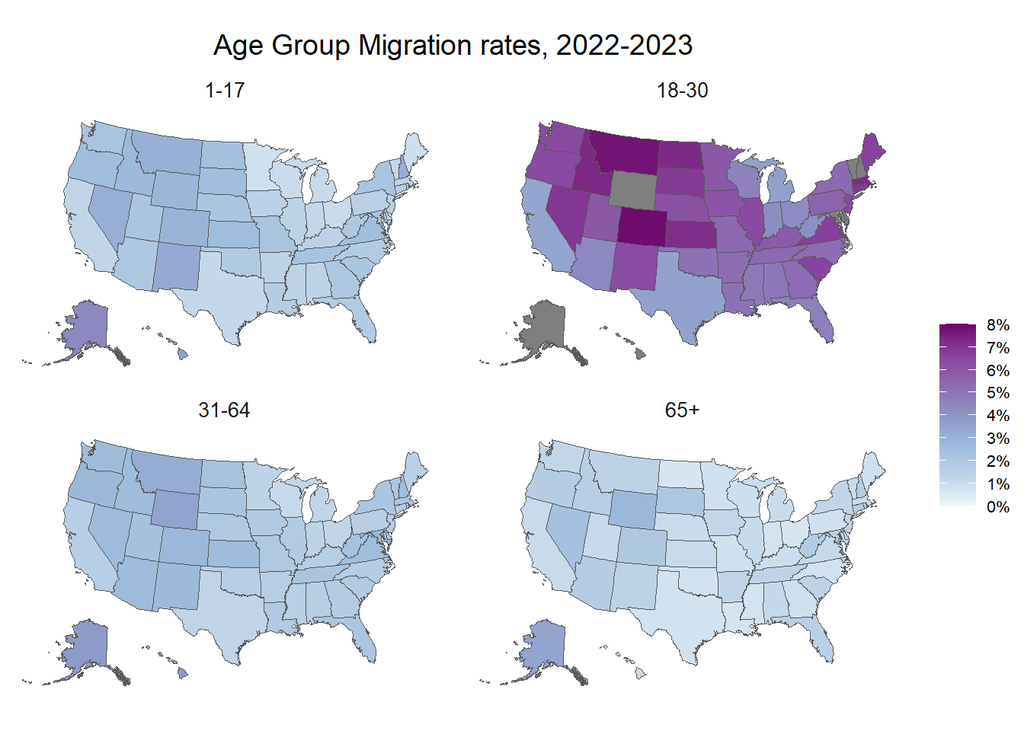

```r
states_shp4 <- states_shp %>%
  right_join(migrate_age_cohorts, by = c("STATE_NAME" = "PREV_STATENAME"))

ggplot() +
  geom_sf(data = states_shp4, aes(fill=interstate_mig_rate_age), size=0.1) +
  coord_sf(crs = "epsg:5070") +
  scale_fill_distiller(name=' ', palette='BuPu',direction=1,
                      breaks=c(.0, .01, .02, .03, .04, .05, .06, .07, .08),
                      labels=label_percent(accuracy = 1),
                      limits=c(0,.08)) +
  labs(title = "Age Group Migration rates, 2022-2023") +
  theme(panel.grid.major = element_blank(),
        panel.grid.minor = element_blank(),
        panel.background = element_blank(),
        axis.line = element_blank(),
        axis.text.x=element_blank(),
        axis.text.y=element_blank(),
        axis.ticks=element_blank(),
        axis.title=element_blank(),
        legend.key.size =  unit(0.25, "in"),
        legend.text = element_text(size=8),
        legend.title = element_text(size=6),
        plot.title = element_text(size=14,hjust = 0.5),
        plot.subtitle = element_text(hjust = 0.5),
        plot.margin=unit(c(1, 1, 1, 1), "points"),
        strip.background = element_rect(fill='white'),
        strip.text.x = element_text(size = 10)) +
  facet_wrap(~agegroup)
```

## 4.11 Calculate location quotient compared to total rates by State and graph that according to each age group

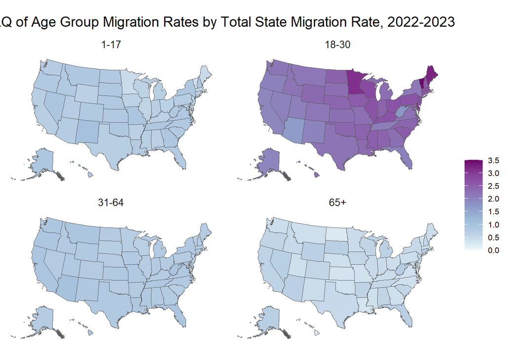

```r
states_shp4 <- states_shp4 %>%
  mutate(
    lq_state_mig_rate_age=interstate_mig_rate_age/interstate_mig_rate_origin)


ggplot() +
  geom_sf(data = states_shp4, aes(fill=lq_state_mig_rate_age), size=0.1) +
  coord_sf(crs = "epsg:5070") +
  scale_fill_distiller(name=' ', palette='BuPu',direction=1,
                      breaks=c(.0, .5, 1, 1.5, 2, 2.5, 3, 3.5),
                      limits=c(0,3.5)) +
  labs(title = "LQ of Age Group Migration Rates by Total State Migration Rate, 2022-2023") +
  theme(panel.grid.major = element_blank(),
        panel.grid.minor = element_blank(),
        panel.background = element_blank(),
        axis.line = element_blank(),
        axis.text.x=element_blank(),
        axis.text.y=element_blank(),
        axis.ticks=element_blank(),
        axis.title=element_blank(),
        legend.key.size =  unit(0.25, "in"),
        legend.text = element_text(size=8),
        legend.title = element_text(size=6),
        plot.title = element_text(size=14,hjust = 0.5),
        plot.subtitle = element_text(hjust = 0.5),
        plot.margin=unit(c(1, 1, 1, 1), "points"),
        strip.background = element_rect(fill='white'),
        strip.text.x = element_text(size = 10)) +
  facet_wrap(~agegroup)
```

Unsurprisingly the age compromising of most college grads and young people contains significantly higher rates of moving compared rest of their respective states. Although it may be hard to tell, old people are moving a decent bit less whereas the 31-64 cohort seems to be relatively consistent with the overall state migration rate

## 4.12 Calculate national rate of migration for age cohorts and compare that by state. I used the none shapefile because there was weird issues here with the geometry messing with the variable being found.

```r
national_cohort_mig_rate <- migrate_age_cohorts %>%
  # st_drop_geometry()
  group_by(agegroup) %>%
  summarise(
    pop_age=sum(pop),
    interstate_mover_age=sum(interstate_movers)) %>%
  mutate(national_age_mig_rate=interstate_mover_age/pop_age) %>%
  ungroup()

gt(national_cohort_mig_rate)
```

| agegroup | pop_age | interstate_mover_age | national_age_mig_rate |
| --- | --- | --- | --- |
| 1-17 | 69091574 | 1180457 | 0.017085 |
| 18-30 | 57034535 | 2993519 | 0.052486 |
| 31-64 | 145967692 | 2765323 | 0.018945 |
| 65+ | 59329416 | 683321 | 0.011517 |

## 4.13 Now we will go ahead and merge this issue to our shapefile, compute the location quotient of national migration rates of the age cohorts compared to the state age cohort migration rate

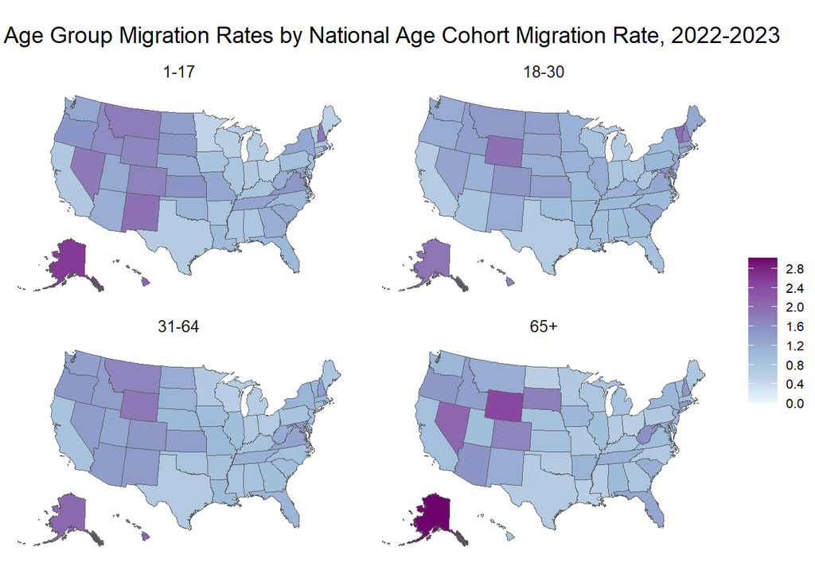

```r
## left_join since we need to keep everything in states_shp4
states_shp4 <- states_shp4 %>%
  right_join(national_cohort_mig_rate, by = "agegroup")

## Calculate location quotient over national migrate rate for age cohort
states_shp4 <- states_shp4 %>%
  mutate(
    lq_mig_rate_cohort=interstate_mig_rate_age/national_age_mig_rate
  )

ggplot() +
  geom_sf(data = states_shp4, aes(fill=lq_mig_rate_cohort), size=0.1) +
  coord_sf(crs = "epsg:5070") +
  scale_fill_distiller(name=' ', palette='BuPu',direction=1,
                      breaks=c(.0, .4, .8, 1.2, 1.6, 2, 2.4, 2.8),
                      limits=c(0, 3.02)) +
  labs(title = "LQ of Age Group Migration Rates by National Age Cohort Migration Rate, 2022-2023") +
  theme(panel.grid.major = element_blank(),
        panel.grid.minor = element_blank(),
        panel.background = element_blank(),
        axis.line = element_blank(),
        axis.text.x=element_blank(),
        axis.text.y=element_blank(),
        axis.ticks=element_blank(),
        axis.title=element_blank(),
        legend.key.size =  unit(0.25, "in"),
        legend.text = element_text(size=8),
        legend.title = element_text(size=6),
        plot.title = element_text(size=14,hjust = 0.5),
        plot.subtitle = element_text(hjust = 0.5),
        plot.margin=unit(c(1, 1, 1, 1), "points"),
        strip.background = element_rect(fill='white'),
        strip.text.x = element_text(size = 10)) +
  facet_wrap(~agegroup)
```

When we compare to the overall age cohorts we can see Alaska is quite a popular state to leave as well as Wyoming both higher in most cohorts. I find it interesting how New Mexico is higher amongst the youngest group but remains only slightly high for other groups. Of course, this location quotient does undermine the overall veracity of younger people migrating but there is not a clear state ahead of the rest except for perhaps wyoming and both Vermont and New Hampshire. I will note that D.C. had quite high for most groups although that cannot be seen well from these maps.